# CodingExample

Win-Vector LLC

September 30, 2015

Show a standard Bayes model encoding of categorical variables (essentially what vtreat does). Notice the variables fool the glm built on top of this data into thinking it has a perfect model on data. This is because the Bayes encoded columns are hiding the consumption of a very larger number of degrees of freedom. They are memorizing things about the training data that are not relations that will hold into production.

```r
bSigma <- 0
print(paste('Bayes model, sigma=',bSigma))
```

```
## [1] "Bayes model, sigma= 0"
```

```r
bCoder <- trainBayesCoder(dTrain,yName,vars,bSigma)
dTrainB <- bCoder$codeFrame(dTrain)
dTestB <- bCoder$codeFrame(dTest)
varsB <- setdiff(colnames(dTrainB),yName)
formulaB <- paste(yName,paste(varsB,collapse=' + '),sep=' ~ ')
modelB <- glm(formulaB,data=dTrainB,family=binomial(link='logit'))
```

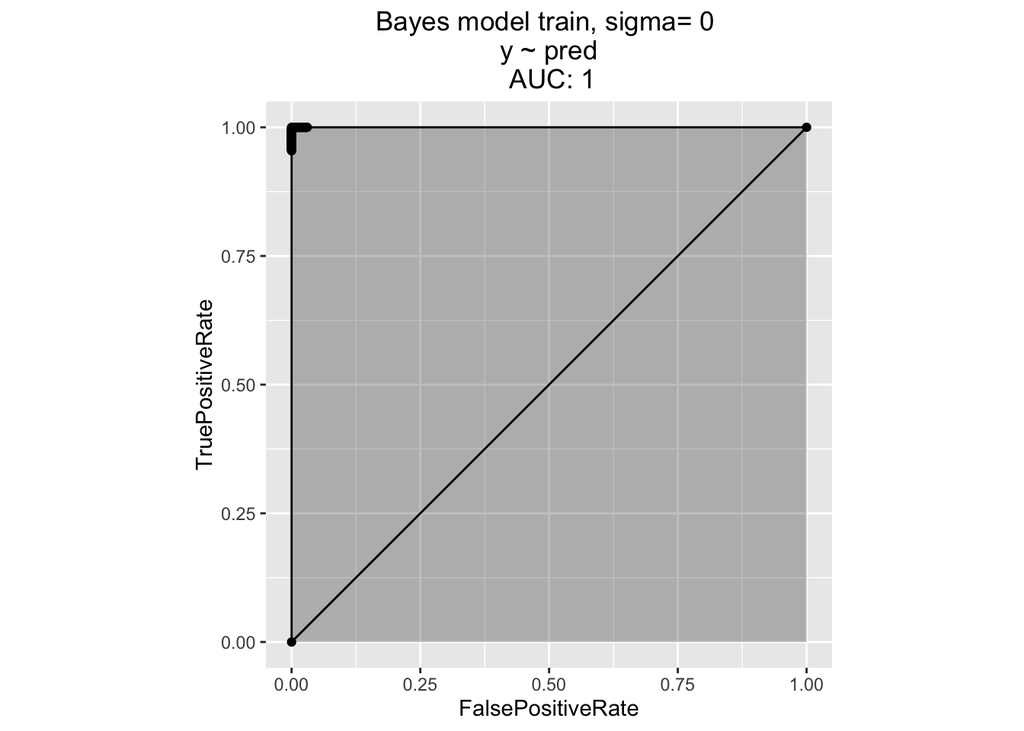

```r
dTrainB$pred <- predict(modelB,newdata=dTrainB,type='response')
print(WVPlots::ROCPlot(dTrainB,'pred',yName,
                       paste('Bayes model train, sigma=',bSigma)))
```

```r
dTestB$pred <- predict(modelB,newdata=dTestB,type='response')
print(errorRate(dTestB$pred,dTestB[[yName]]))
```

```
## [1] 0.4971
```

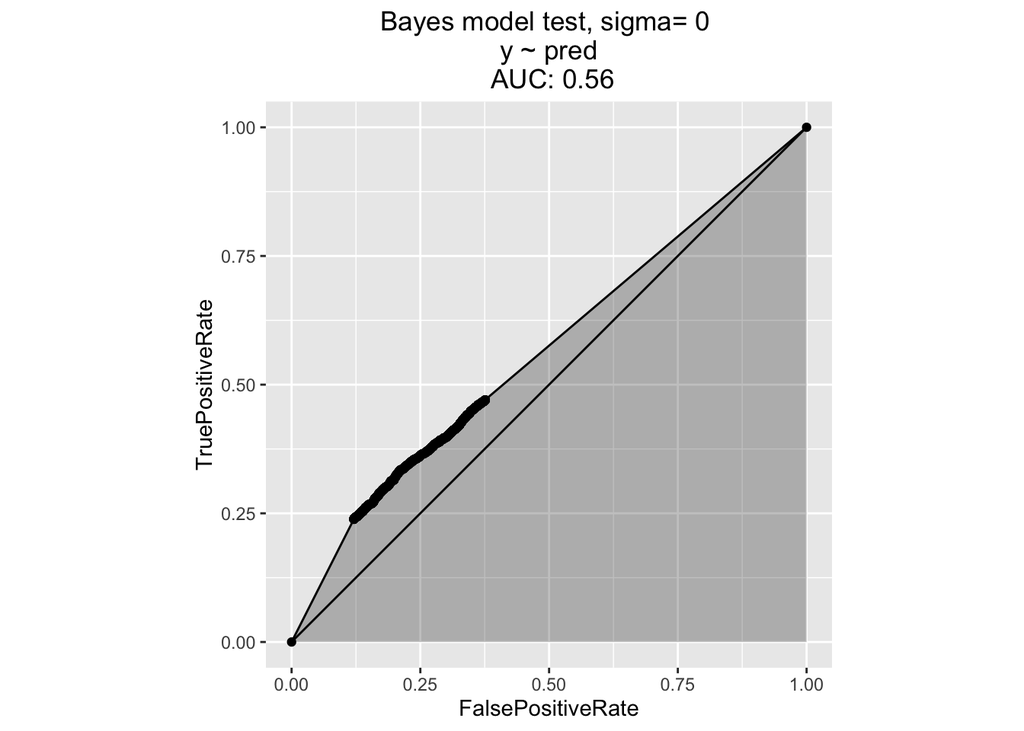

```r
print(WVPlots::ROCPlot(dTestB,'pred',yName,
                       paste('Bayes model test, sigma=',bSigma)))
```

Misha Bilenko presented a related technique [“learning from counts”](http://blogs.technet.com/b/machinelearning/archive/2015/02/17/big-learning-made-easy-with-counts.aspx) that encodes the large categorical as four columns such that the Bayes model is a simple function of the columns. It works a bit better, but exhibits the same over-fitting issue.

```r
cSigma <- 0
print(paste('count model, sigma=',cSigma))
```

```
## [1] "count model, sigma= 0"
```

```r
cCoder <- trainCountCoder(dTrain,yName,vars,cSigma)
dTrainC <- cCoder$codeFrame(dTrain)
dTestC <- cCoder$codeFrame(dTest)
varsC <- setdiff(colnames(dTrainC),yName)
formulaC <- paste(yName,paste(varsC,collapse=' + '),sep=' ~ ')
modelC <- glm(formulaC,data=dTrainC,family=binomial(link='logit'))
dTrainC$pred <- predict(modelC,newdata=dTrainC,type='response')
```

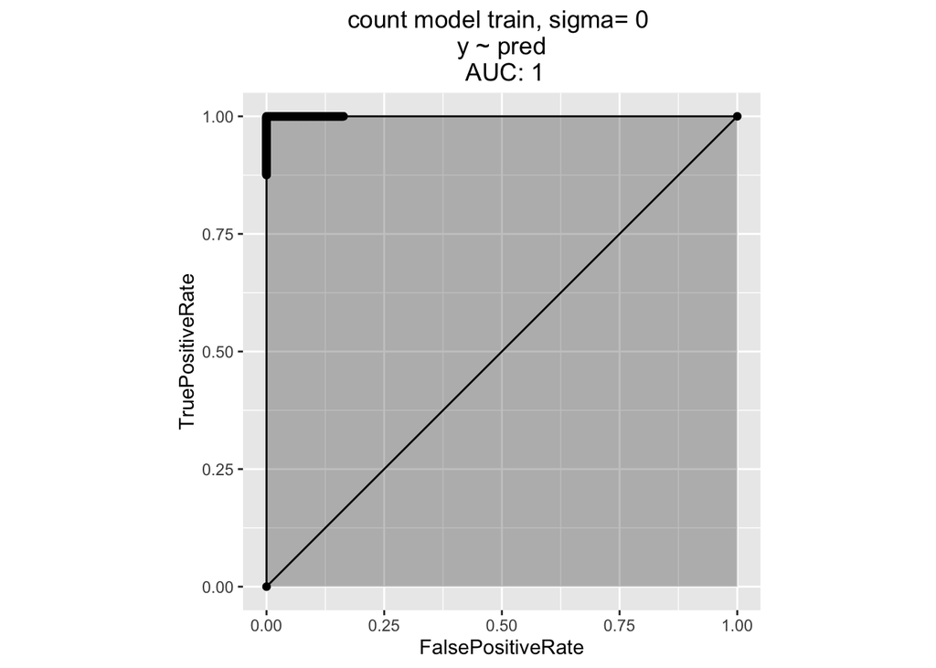

```r
print(WVPlots::ROCPlot(dTrainC,'pred',yName,
                       paste('count model train, sigma=',cSigma)))
```

```r
dTestC$pred <- predict(modelC,newdata=dTestC,type='response')
print(errorRate(dTestC$pred,dTestC[[yName]]))
```

```
## [1] 0.3437
```

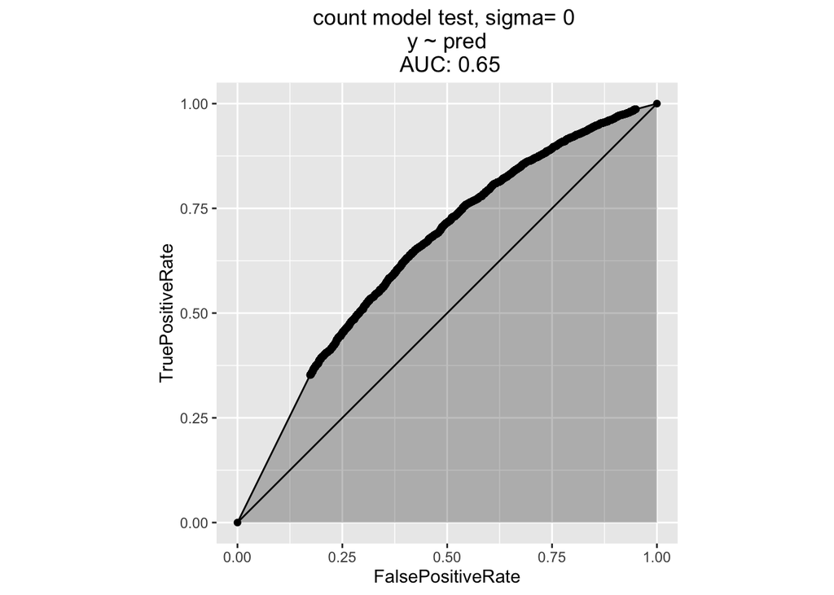

```r
print(WVPlots::ROCPlot(dTestC,'pred',yName,
                       paste('count model test, sigma=',cSigma)))
```

One extremely statistically efficient way to reserve a disjoint set of data for building the variable encodings is a Jackknife technique. It works very well.

```r
print('Bayes model, jackknifed')
```

```
## [1] "Bayes model, jackknifed"
```

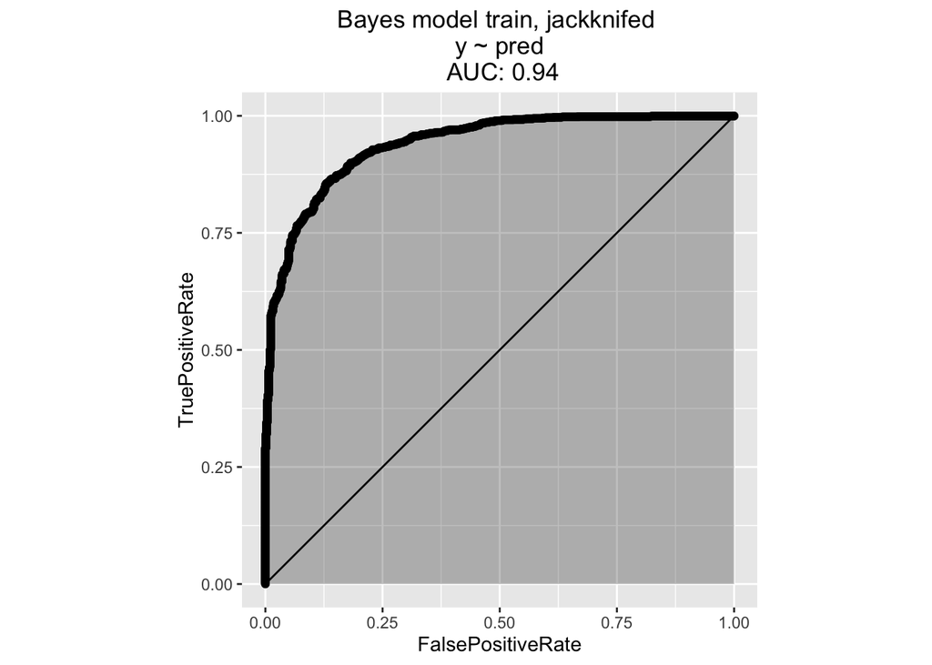

```r
bCoder <- trainBayesCoder(dTrain,yName,vars,0)
# dTrainB <- bCoder$codeFrame(dTrain) # naive coding, fails
dTrainB <- jackknifeBayesCode(dTrain,yName,vars)
dTestB <- bCoder$codeFrame(dTest)
varsB <- setdiff(colnames(dTrainB),yName)
formulaB <- paste(yName,paste(varsB,collapse=' + '),sep=' ~ ')
modelB <- glm(formulaB,data=dTrainB,family=binomial(link='logit'))
dTrainB$pred <- predict(modelB,newdata=dTrainB,type='response')
print(WVPlots::ROCPlot(dTrainB,'pred',yName,
                       'Bayes model train, jackknifed'))
```

```r
dTestB$pred <- predict(modelB,newdata=dTestB,type='response')
print(errorRate(dTestB$pred,dTestB[[yName]]))
```

```
## [1] 0.1446
```

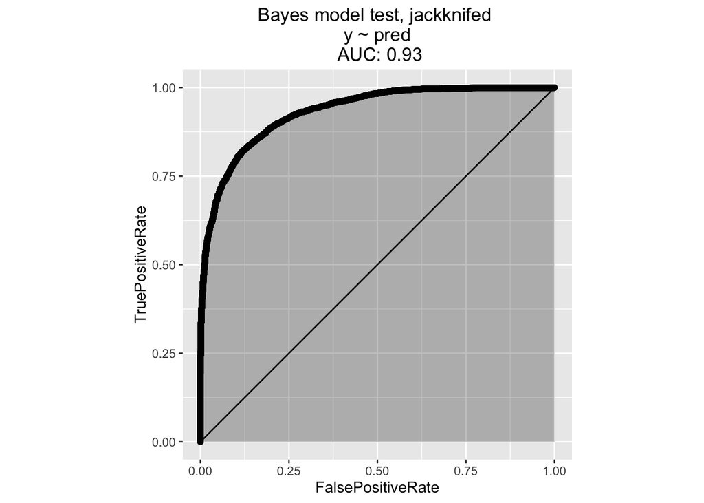

```r
print(WVPlots::ROCPlot(dTestB,'pred',yName,
                       'Bayes model test, jackknifed'))
```

```r
print('count model, jackknifed')
```

```
## [1] "count model, jackknifed"
```

```r
cCoder <- trainCountCoder(dTrain,yName,vars,0)
# dTrainC <- cCoder$codeFrame(dTrain) # naive coding, fails
dTrainC <- jackknifeCountCode(dTrain,yName,vars)
dTestC <- cCoder$codeFrame(dTest)
varsC <- setdiff(colnames(dTrainC),yName)
formulaC <- paste(yName,paste(varsC,collapse=' + '),sep=' ~ ')
modelC <- glm(formulaC,data=dTrainC,family=binomial(link='logit'))
dTrainC$pred <- predict(modelC,newdata=dTrainC,type='response')
```

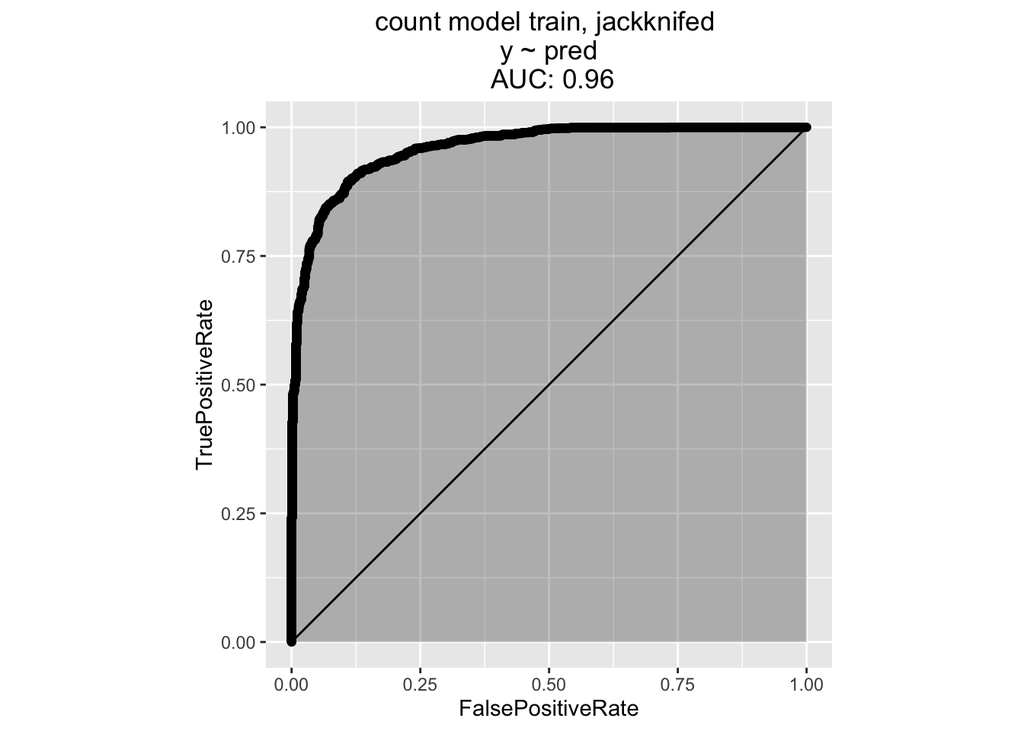

```r
print(WVPlots::ROCPlot(dTrainC,'pred',yName,
                       'count model train, jackknifed'))
```

```r
dTestC$pred <- predict(modelC,newdata=dTestC,type='response')
print(errorRate(dTestC$pred,dTestC[[yName]]))
```

```
## [1] 0.1761
```

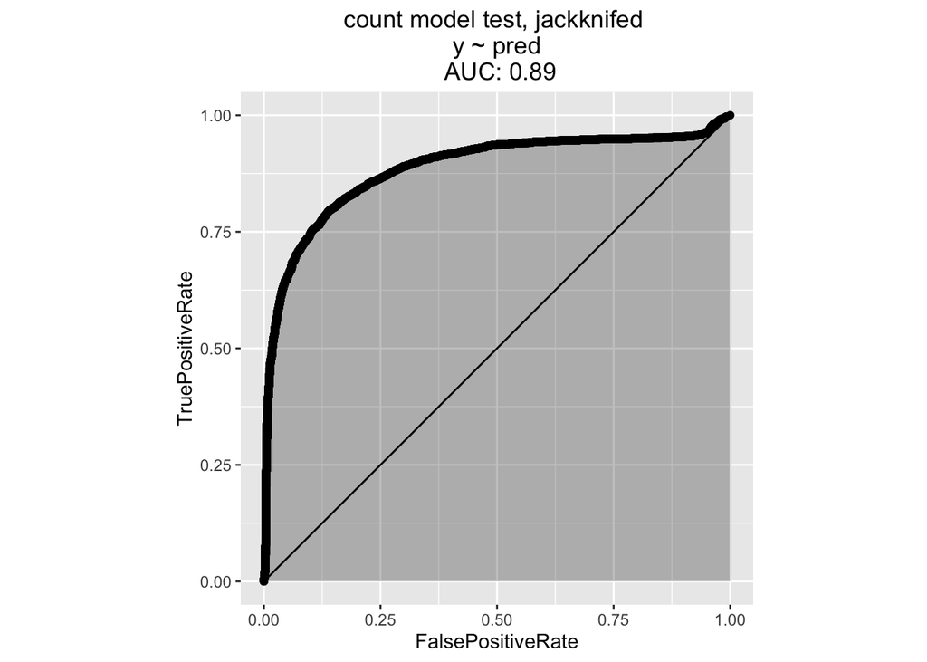

```r
print(WVPlots::ROCPlot(dTestC,'pred',yName,
                       'count model test, jackknifed'))
```

Our advised best practice for vtreat is to reserve one set for variable encoding, one for model training, and a final one for test. This also works well if you have enough data.

```r
print("vtreat split model")
```

```
## [1] "vtreat split model"
```

```r
isCal <- runif(nrow(dTrain))<0.5
dTrainC <- dTrain[isCal,]
dTrainT <- dTrain[!isCal,]
treatments <- vtreat::designTreatmentsC(dTrainC,vars,yName,TRUE,
                                        rareSig=1.0,
                                        smFactor=5.0,
                                        verbose=FALSE,
                                        parallelCluster=cl)
print(treatments$scoreFrame)
```

```
##                varName varMoves         psig          sig         csig
## 1     x1_lev_x.x1.c001     TRUE 2.917299e-01 2.868866e-01 2.868866e-01
## 2     x1_lev_x.x1.c002     TRUE 2.028419e-02 1.854923e-02 1.854923e-02
## 3     x1_lev_x.x1.c003     TRUE 1.020428e-02 7.439715e-03 7.439715e-03
## 4     x1_lev_x.x1.c004     TRUE 1.255273e-03 1.507445e-03 1.507445e-03
## 5     x1_lev_x.x1.c006     TRUE 8.450697e-01 8.446478e-01 8.446478e-01
## 6     x1_lev_x.x1.c007     TRUE 1.025439e-02 8.208171e-03 8.208171e-03
## 7     x1_lev_x.x1.c008     TRUE 1.249322e-01 1.308040e-01 1.308040e-01
## 8     x1_lev_x.x1.c009     TRUE 9.965007e-03 1.070152e-02 1.070152e-02
## 9     x1_lev_x.x1.c010     TRUE 5.227751e-01 5.242979e-01 5.242979e-01
## 10             x1_catP     TRUE 5.557512e-02 5.538933e-02 5.538933e-02
## 11             x1_catB     TRUE 1.928549e-07 2.050436e-07 2.050436e-07
## 12    x2_lev_x.x2.c001     TRUE 3.861848e-01 3.783078e-01 3.783078e-01
## 13    x2_lev_x.x2.c002     TRUE 2.282425e-02 1.991938e-02 1.991938e-02
## 14    x2_lev_x.x2.c004     TRUE 3.998146e-08 6.552444e-08 6.552444e-08
```

[output cut: 325 more lines]

```r
dTrainV <- vtreat::prepare(treatments,dTrainT,pruneSig=0.05,
                           parallelCluster=cl)
dTestV <- vtreat::prepare(treatments,dTest,pruneSig=0.05,
                          parallelCluster=cl)
varsV <- setdiff(colnames(dTrainV),yName)
formulaV <- paste(yName,paste(varsV,collapse=' + '),sep=' ~ ')
modelV <- glm(formulaV,data=dTrainV,family=binomial(link='logit'))
dTestV$pred <- predict(modelV,newdata=dTestV,type='response')
print(errorRate(dTestV$pred,dTestV[[yName]]))
```

```
## [1] 0.1399
```

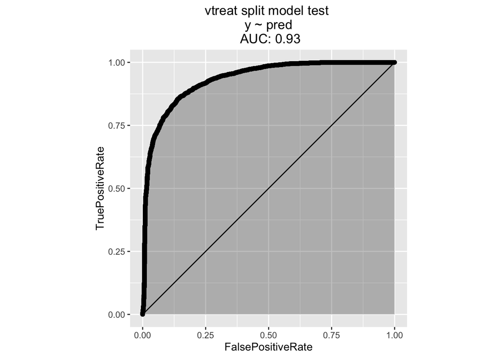

```r
print(WVPlots::ROCPlot(dTestV,'pred',yName,
                       paste('vtreat split model test')))
```

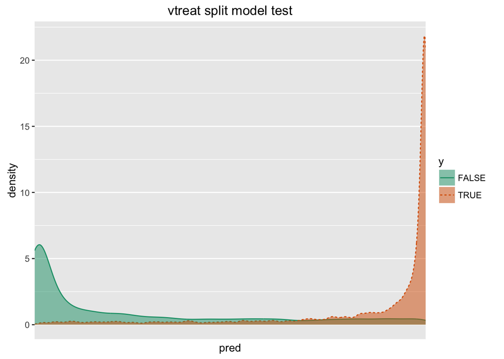

```r
print(WVPlots::DoubleDensityPlot(dTestV,'pred',yName,
                       paste('vtreat split model test')))
```

We can also use all our data for both encoding construction and training prune out rare levels before they are allowed into the transformed variables.

```r
print("vtreat prune model")
```

```
## [1] "vtreat prune model"
```

```r
treatments <- vtreat::designTreatmentsC(dTrain,vars,yName,TRUE,
                                        rareSig=0.3,
                                        smFactor=5.0,
                                        verbose=FALSE,
                                        parallelCluster=cl)
print(treatments$scoreFrame)
```

```
##                varName varMoves         psig          sig         csig
## 1     x1_lev_x.x1.c001     TRUE 1.826601e-01 1.787441e-01 1.787441e-01
## 2     x1_lev_x.x1.c002     TRUE 5.926038e-02 5.724801e-02 5.724801e-02
## 3     x1_lev_x.x1.c003     TRUE 6.109184e-03 4.806910e-03 4.806910e-03
## 4     x1_lev_x.x1.c004     TRUE 1.342531e-02 1.437233e-02 1.437233e-02
## 5     x1_lev_x.x1.c007     TRUE 1.322011e-05 6.161930e-06 6.161930e-06
## 6     x1_lev_x.x1.c008     TRUE 9.512915e-03 1.089286e-02 1.089286e-02
## 7     x1_lev_x.x1.c009     TRUE 1.781153e-04 2.069593e-04 2.069593e-04
## 8     x1_lev_x.x1.c010     TRUE 1.358947e-01 1.389091e-01 1.389091e-01
## 9              x1_catP     TRUE 2.706141e-03 2.731422e-03 2.731422e-03
## 10             x1_catB     TRUE 1.411856e-08 1.345423e-08 1.345423e-08
## 11    x2_lev_x.x2.c001     TRUE 8.238100e-02 7.503133e-02 7.503133e-02
## 12    x2_lev_x.x2.c002     TRUE 9.127911e-04 6.888745e-04 6.888745e-04
## 13    x2_lev_x.x2.c004     TRUE 2.426061e-17 1.023999e-16 1.023999e-16
## 14    x2_lev_x.x2.c007     TRUE 3.010308e-04 2.513474e-04 2.513474e-04
```

[output cut: 285 more lines]

```r
dTrainV <- vtreat::prepare(treatments,dTrain,pruneSig=0.05,
                           parallelCluster=cl)
dTestV <- vtreat::prepare(treatments,dTest,pruneSig=0.05,
                          parallelCluster=cl)
varsV <- setdiff(colnames(dTrainV),yName)
formulaV <- paste(yName,paste(varsV,collapse=' + '),sep=' ~ ')
modelV <- glm(formulaV,data=dTrainV,family=binomial(link='logit'))
dTrainV$pred <- predict(modelV,newdata=dTrainV,type='response')
```

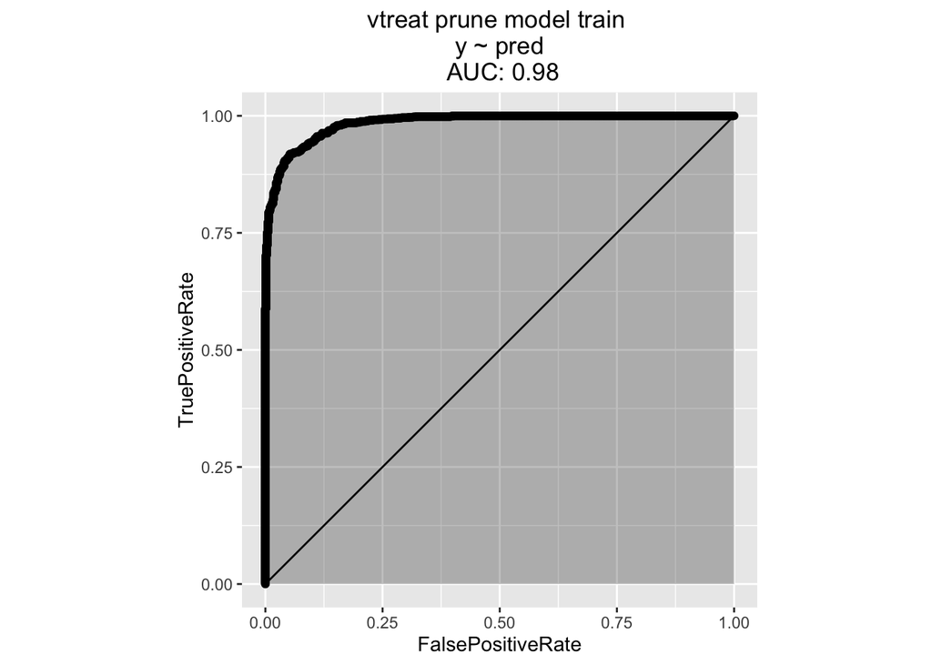

```r
print(WVPlots::ROCPlot(dTrainV,'pred',yName,
                       paste('vtreat prune model train')))
```

```r
dTestV$pred <- predict(modelV,newdata=dTestV,type='response')
print(errorRate(dTestV$pred,dTestV[[yName]]))
```

```
## [1] 0.1554
```

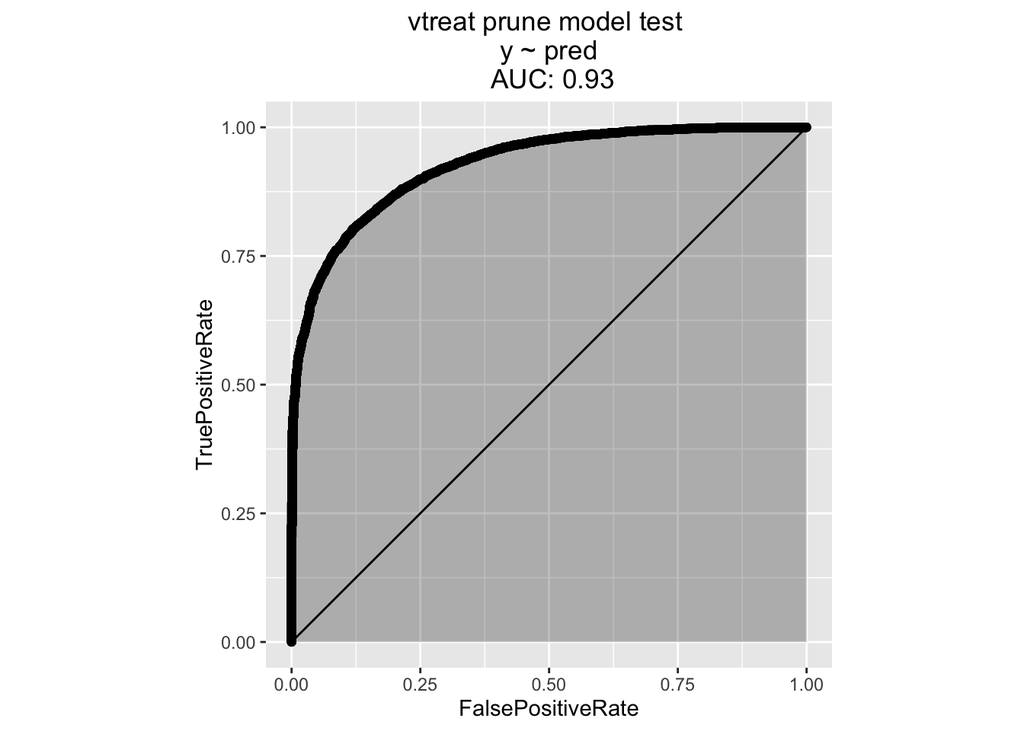

```r
print(WVPlots::ROCPlot(dTestV,'pred',yName,
                       paste('vtreat prune model test')))
```

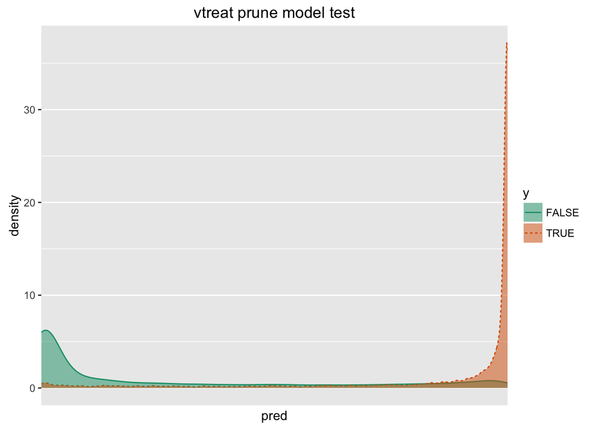

```r
print(WVPlots::DoubleDensityPlot(dTestV,'pred',yName,
                       paste('vtreat prune model test')))
```

```r
# devtools::install_github("WinVector/vtreat")  # to get 0.5.22 version with vtreat::mkCrossFrameCExperiment()
# library('vtreat')

print("vtreat cross model")
```

```
## [1] "vtreat cross model"
```

```r
crossExpmt <- vtreat::mkCrossFrameCExperiment(dTrain,vars,yName,TRUE,
                                        rareSig=1.0,
                                        smFactor=5.0,
                                        parallelCluster=cl)
treatments <- crossExpmt$treatments
dTrainV <- crossExpmt$crossFrame
print(treatments$scoreFrame)
```

```
##                varName varMoves         psig          sig         csig
## 1     x1_lev_x.x1.c001     TRUE 1.826601e-01 1.787441e-01 1.787441e-01
## 2     x1_lev_x.x1.c002     TRUE 5.926038e-02 5.724801e-02 5.724801e-02
## 3     x1_lev_x.x1.c003     TRUE 6.109184e-03 4.806910e-03 4.806910e-03
## 4     x1_lev_x.x1.c004     TRUE 1.342531e-02 1.437233e-02 1.437233e-02
## 5     x1_lev_x.x1.c006     TRUE 3.027315e-01 2.994278e-01 2.994278e-01
## 6     x1_lev_x.x1.c007     TRUE 1.322011e-05 6.161930e-06 6.161930e-06
## 7     x1_lev_x.x1.c008     TRUE 9.512915e-03 1.089286e-02 1.089286e-02
## 8     x1_lev_x.x1.c009     TRUE 1.781153e-04 2.069593e-04 2.069593e-04
## 9     x1_lev_x.x1.c010     TRUE 1.358947e-01 1.389091e-01 1.389091e-01
## 10             x1_catP     TRUE 3.000511e-03 3.030197e-03 3.030197e-03
## 11             x1_catB     TRUE 2.763594e-12 2.549581e-12 2.549581e-12
## 12    x2_lev_x.x2.c001     TRUE 8.238100e-02 7.503133e-02 7.503133e-02
## 13    x2_lev_x.x2.c002     TRUE 9.127911e-04 6.888745e-04 6.888745e-04
## 14    x2_lev_x.x2.c004     TRUE 2.426061e-17 1.023999e-16 1.023999e-16
```

[output cut: 325 more lines]

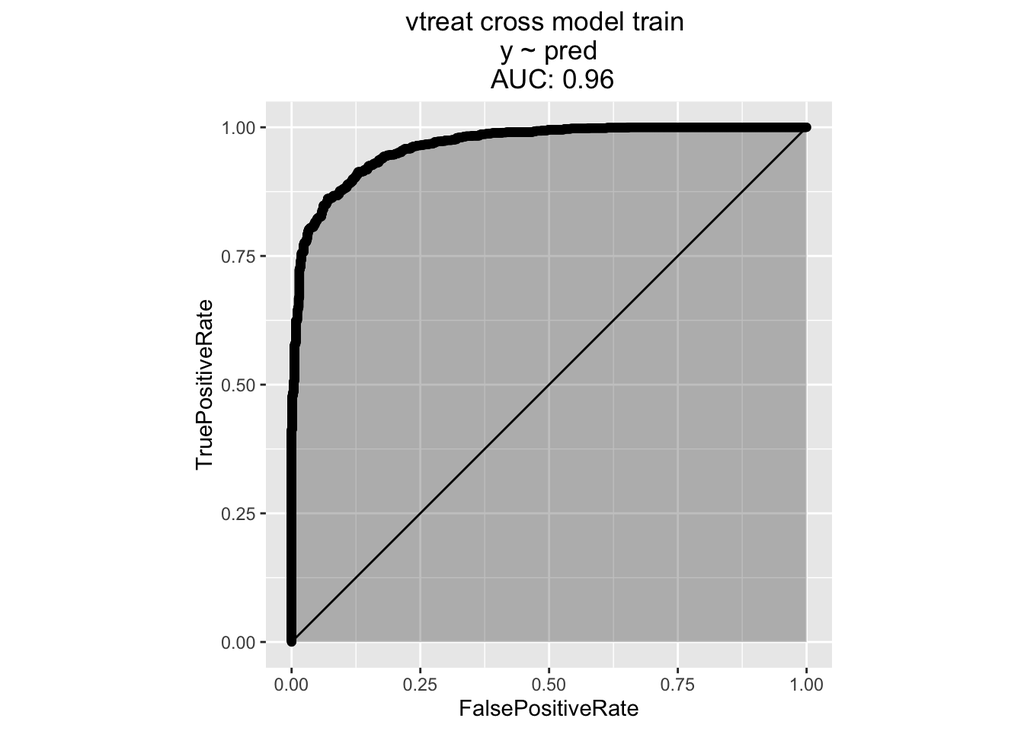

```r
varsV <- treatments$scoreFrame$varName[treatments$scoreFrame$sig<=0.05]
dTestV <- vtreat::prepare(treatments,dTest,pruneSig=c(),
                          varRestriction=varsV,
                          parallelCluster=cl)
formulaV <- paste(yName,paste(varsV,collapse=' + '),sep=' ~ ')
modelV <- glm(formulaV,data=dTrainV,family=binomial(link='logit'))
dTrainV$pred <- predict(modelV,newdata=dTrainV,type='response')
print(WVPlots::ROCPlot(dTrainV,'pred',yName,
                       paste('vtreat cross model train')))
```

```r
dTestV$pred <- predict(modelV,newdata=dTestV,type='response')
print(errorRate(dTestV$pred,dTestV[[yName]]))
```

```
## [1] 0.1253
```

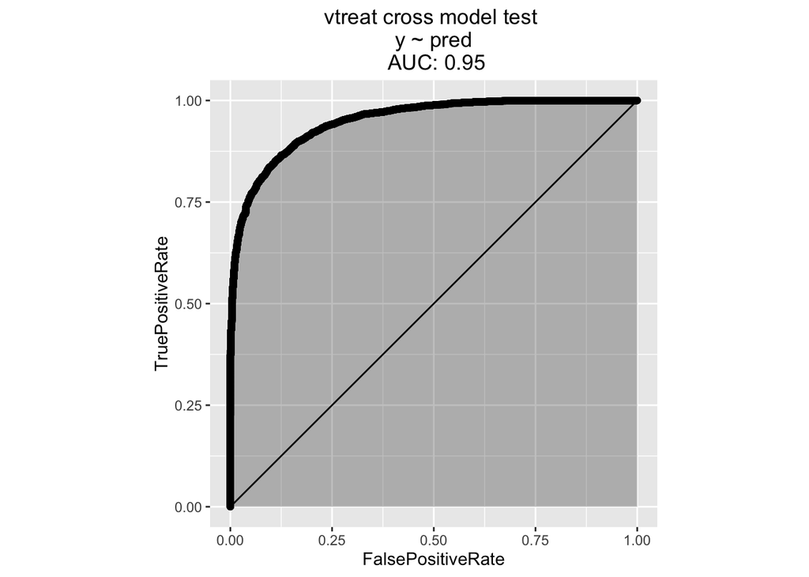

```r
print(WVPlots::ROCPlot(dTestV,'pred',yName,
                       paste('vtreat cross model test')))
```

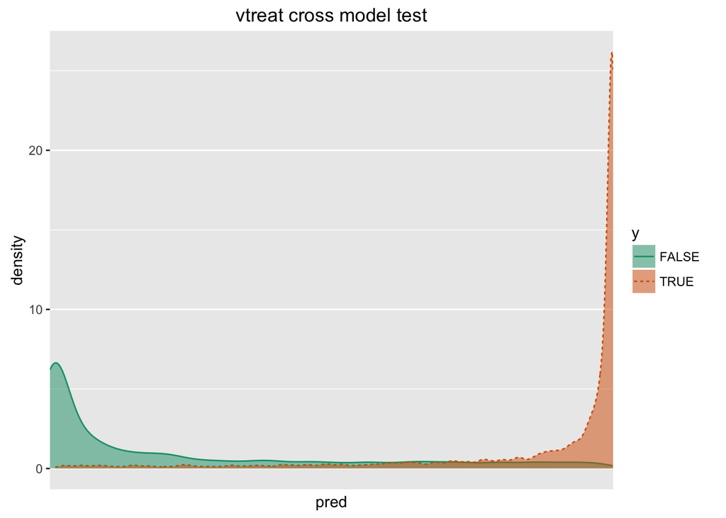

```r
print(WVPlots::DoubleDensityPlot(dTestV,'pred',yName,
                       paste('vtreat cross model test')))
```

The point is, many variations work well.

Also Misha Bilenko introduced an [application of differential privacy](http://conf.dato.com/speakers/dr-misha-bilenko/) to protect from over-fitting effects. It is a bit subtle, but also works well. For more on this see [our series on differential privacy](http://www.win-vector.com/blog/2015/11/our-differential-privacy-mini-series/).

```r
cSigma <- cSigmaBest
print(paste('count model, sigma=',cSigma))
```

```
## [1] "count model, sigma= 12"
```

```r
cCoder <- trainCountCoder(dTrain,yName,vars,cSigma)
dTrainC <- cCoder$codeFrame(dTrain)
dTestC <- cCoder$codeFrame(dTest)
varsC <- setdiff(colnames(dTrainC),yName)
formulaC <- paste(yName,paste(varsC,collapse=' + '),sep=' ~ ')
modelC <- glm(formulaC,data=dTrainC,family=binomial(link='logit'))
dTrainC$pred <- predict(modelC,newdata=dTrainC,type='response')
```

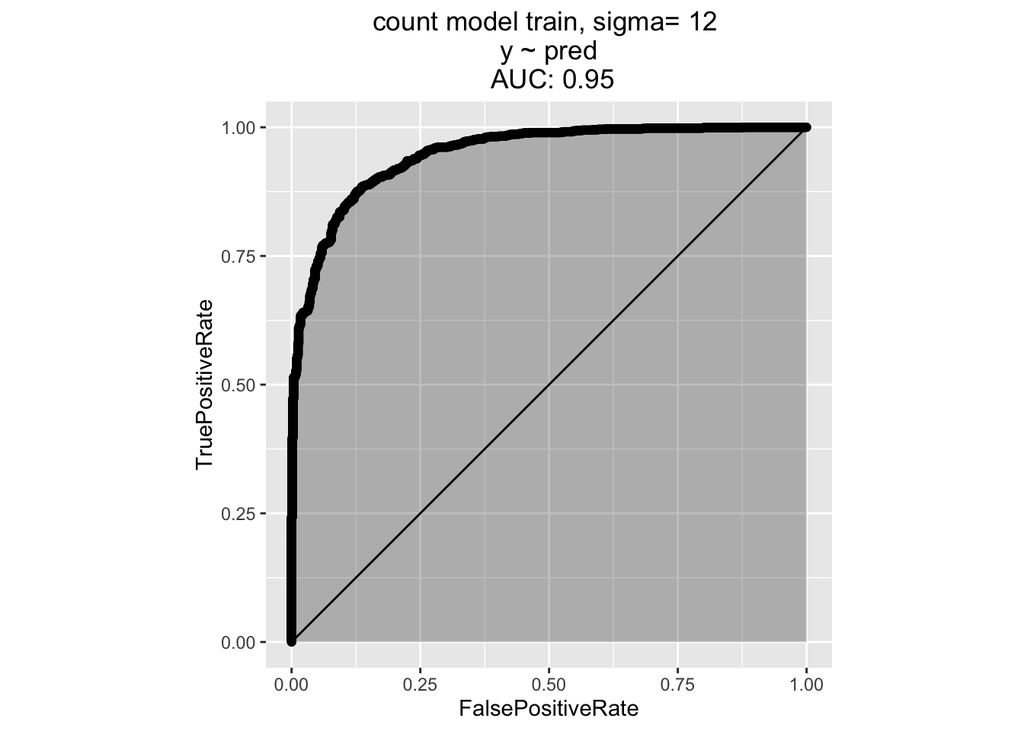

```r
print(WVPlots::ROCPlot(dTrainC,'pred',yName,
                       paste('count model train, sigma=',cSigma)))
```

```r
dTestC$pred <- predict(modelC,newdata=dTestC,type='response')
print(errorRate(dTestC$pred,dTestC[[yName]]))
```

```
## [1] 0.1933
```

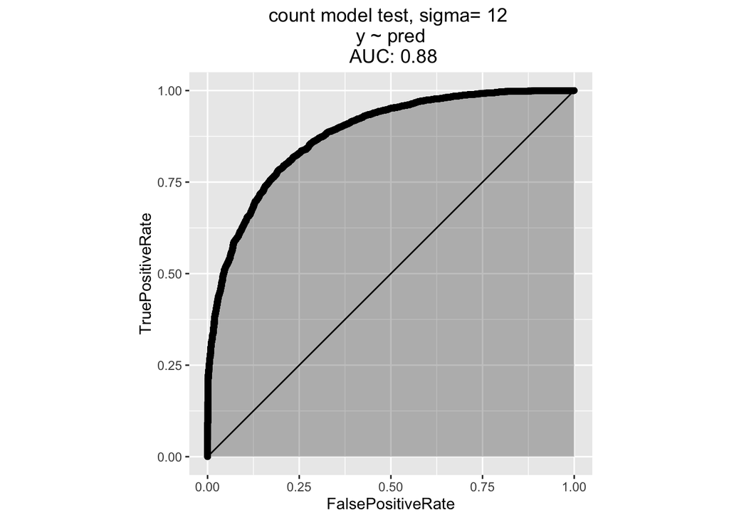

```r
print(WVPlots::ROCPlot(dTestC,'pred',yName,
                       paste('count model test, sigma=',cSigma)))
```

```r
bSigma <- bSigmaBest
print(paste('Bayes model, sigma=',bSigma))
```

```
## [1] "Bayes model, sigma= 8"
```

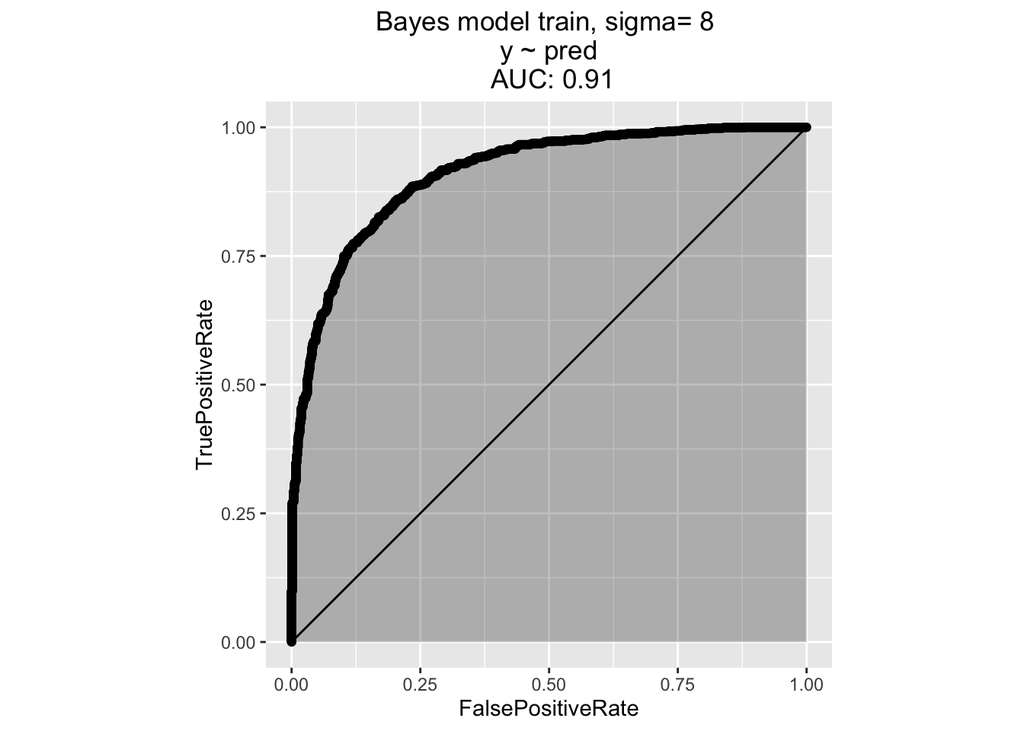

```r
bCoder <- trainBayesCoder(dTrain,yName,vars,bSigma)
dTrainB <- bCoder$codeFrame(dTrain)
dTestB <- bCoder$codeFrame(dTest)
varsB <- setdiff(colnames(dTrainB),yName)
formulaB <- paste(yName,paste(varsB,collapse=' + '),sep=' ~ ')
modelB <- glm(formulaB,data=dTrainB,family=binomial(link='logit'))
dTrainB$pred <- predict(modelB,newdata=dTrainB,type='response')
print(WVPlots::ROCPlot(dTrainB,'pred',yName,
                       paste('Bayes model train, sigma=',bSigma)))
```

```r
dTestB$pred <- predict(modelB,newdata=dTestB,type='response')
print(errorRate(dTestB$pred,dTestB[[yName]]))
```

```
## [1] 0.2256
```

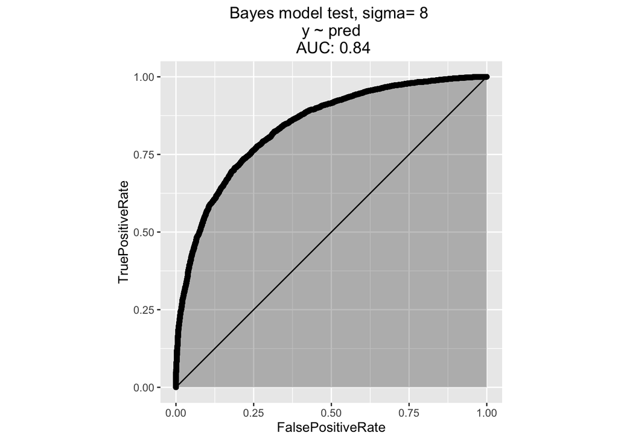

```r
print(WVPlots::ROCPlot(dTestB,'pred',yName,
                       paste('Bayes model test, sigma=',bSigma)))
```

```r
if(!is.null(cl)) {
  parallel::stopCluster(cl)
  cl <- NULL
}
```